# Portfoliomanagement and Financial Analysis - Assignment 2

Submit until Monday 2020-09-28, 13:00

Schwaiger, Dominik

```r
pacman::p_load(tidyverse,tidyquant,FFdownload,tsibble)
```

**Please** remember to put your assignment solutions in `rmd` format using **many** chunks and putting readable text in between, similar to my examples given in Research Methods and Assignment 1! Also, each student has to select his own set of 10 stocks having data available as of `2000-01-01`. Select by Sharpe-ratio, dominance or any other method (e.g. matching your first name).

I chose: - Amazon (AMZN) - Adobe (ADBE) - Microsoft (MSFT) - American Airlines (AAL) - Procter and Gamble (PG) - American Express (AXP) - Bank of America (BAC) - Apple (AAPL) - AT&T (T) - Caterpillar (CAT)

Now, we download the data:

```r
AMZN <- tq_get("AMZN", get = "stock.prices", from =  "2000-01-01", to = "2020-09-17")
ADBE <- tq_get("ADBE", get = "stock-prices", from = "2000-01-01", to = "2020-09-17")
MSFT <- tq_get("MSFT", get = "stock.prices", from =  "2000-01-01", to = "2020-09-17")
AAL <- tq_get("MSFT", get = "stock.prices", from = "2000-01-01", to = "2020-09-17")
PG <- tq_get("MSFT", get = "stock.prices", from = "2000-01-01", to = "2020-09-17")
AXP <- tq_get("CSCO", get = "stock.prices", from =  "2000-01-01", to = "2020-09-17")
BAC <- tq_get("QCOM", get = "stock.prices", from =  "2000-01-01", to = "2020-09-17")
AAPL <- tq_get("ADBE", get = "stock.prices", from =  "2000-01-01", to = "2020-09-17")
T <- tq_get("NVDA", get = "stock.prices", from =  "2000-01-01", to = "2020-09-17")
CAT <- tq_get("AMGN", get = "stock.prices", from =  "2000-01-01", to = "2020-09-17")
```

## Exercise 1: Performance Analysis of Portfolios

Create (using four of the ten stocks) multiple portfolios using `tq_portfolio()`: * an equally weighted one, * a market-value weighted one, and * one where you create a trading strategy according to https://www.datacamp.com/community/tutorials/r-trading-tutorial - use the tools in the tidyquant package!! Trade your four stocks in a way that Portfolios weights (in sum) do never exceed +-1.

DO a performance analysis a la `vignette("TQ05-performance-analysis-with-tidyquant")`.

For the first exercice, I selected the following stocks: - Amazon (AMZN) - Adobe (ADBE) - Microsoft (MSFT) - American Airlines (AAL) First, I want to get all returns for the stocks in one tibble and rename the column return

```r
monthly_returns_stocks <- c("AMZN", "ADBE", "MSFT", "AAL") %>%
tq_get(get = "stock.prices", from = "2000-01-01", to = "2020-09-17") %>%
group_by(symbol)%>%
tq_transmute(adjusted, periodReturn, period = "monthly", col_rename =  "Ra")
monthly_returns_stocks
```

| symbol | date | Ra |
| --- | --- | --- |
| AMZN | 2000-01-31 | -0.2776223776 |
| AMZN | 2000-02-29 | 0.0667957406 |
| AMZN | 2000-03-31 | -0.0272232305 |
| AMZN | 2000-04-28 | -0.1763059701 |
| AMZN | 2000-05-31 | -0.1245753114 |
| AMZN | 2000-06-30 | -0.2483829237 |
| AMZN | 2000-07-31 | -0.1703958692 |
| AMZN | 2000-08-31 | 0.3775933610 |
| AMZN | 2000-09-29 | -0.0737951807 |
| AMZN | 2000-10-31 | -0.0471544715 |

[output cut: 918 more lines]

As a baseline, I will use the S&P500, because it includes the largest listed US-companies.

```r
monthly_returns_baseline <- "^GSPC" %>%
tq_get(get = "stock.prices", from = "2000-01-01", to = "2020-09-17") %>%
tq_transmute(adjusted, periodReturn, period = "monthly", col_rename = "Rb")
monthly_returns_baseline
```

| date | Rb |
| --- | --- |
| 2000-01-31 | -4.175314e-02 |
| 2000-02-29 | -2.010808e-02 |
| 2000-03-31 | 9.671983e-02 |
| 2000-04-28 | -3.079576e-02 |
| 2000-05-31 | -2.191505e-02 |
| 2000-06-30 | 2.393355e-02 |
| 2000-07-31 | -1.634128e-02 |
| 2000-08-31 | 6.069911e-02 |
| 2000-09-29 | -5.348297e-02 |
| 2000-10-31 | -4.949486e-03 |

[output cut: 239 more lines]

Now, I want to aggregate the portfolios. Therefore, I grow my portfoloios, scaling single portfolio to many portfolios.

```r
mult_monthly_returns_stocks <- monthly_returns_stocks %>%
tq_repeat_df(n = 3)
```

```
Ungrouping data frame groups: symbol
```

```r
mult_monthly_returns_stocks
```

| portfolio | symbol | date | Ra |
| --- | --- | --- | --- |
| 1 | AMZN | 2000-01-31 | -0.2776223776 |
| 1 | AMZN | 2000-02-29 | 0.0667957406 |
| 1 | AMZN | 2000-03-31 | -0.0272232305 |
| 1 | AMZN | 2000-04-28 | -0.1763059701 |
| 1 | AMZN | 2000-05-31 | -0.1245753114 |
| 1 | AMZN | 2000-06-30 | -0.2483829237 |
| 1 | AMZN | 2000-07-31 | -0.1703958692 |
| 1 | AMZN | 2000-08-31 | 0.3775933610 |
| 1 | AMZN | 2000-09-29 | -0.0737951807 |
| 1 | AMZN | 2000-10-31 | -0.0471544715 |

[output cut: 990 more lines]

First, we want to deal with the equally-weighted portfolio. Using our four stocks, we weigh each one exactly 25%.

```r
stock_returns_monthly <- c("AMZN", "ADBE", "MSFT","AAL") %>%
tq_get(get  = "stock.prices", from = "2000-01-01",to   = "2020-09-17") %>%
group_by(symbol) %>%
tq_transmute(select=adjusted,mutate_fun= periodReturn,period="monthly",col_rename = "Ra")
```

Secondly, we want to get baseline asset returns. Here, we make the same as Steps 1B and 2B from the Single Portfolio example.

```r
baseline_returns_monthly <- "XLK" %>%
tq_get(get  = "stock.prices",from = "2000-01-01",to   = "2020-09-17") %>%
tq_transmute(select     = adjusted,mutate_fun = periodReturn,period     = "monthly",col_rename = "Rb")
stock_returns_monthly_multi <- stock_returns_monthly %>%
tq_repeat_df(n = 3)
```

```
Ungrouping data frame groups: symbol
```

```r
stock_returns_monthly_multi
```

| portfolio | symbol | date | Ra |
| --- | --- | --- | --- |
| 1 | AMZN | 2000-01-31 | -0.2776223776 |
| 1 | AMZN | 2000-02-29 | 0.0667957406 |
| 1 | AMZN | 2000-03-31 | -0.0272232305 |
| 1 | AMZN | 2000-04-28 | -0.1763059701 |
| 1 | AMZN | 2000-05-31 | -0.1245753114 |
| 1 | AMZN | 2000-06-30 | -0.2483829237 |
| 1 | AMZN | 2000-07-31 | -0.1703958692 |
| 1 | AMZN | 2000-08-31 | 0.3775933610 |
| 1 | AMZN | 2000-09-29 | -0.0737951807 |
| 1 | AMZN | 2000-10-31 | -0.0471544715 |

[output cut: 990 more lines]

Since I want to have equally-weighted portfolios, my weights should look as follows:

```r
weights <- c(0.25, 0.25, 0.25, 0.25,
             0.25, 0.25, 0.25, 0.25,
             0.25, 0.25, 0.25, 0.25)

stocks <- c("AMZN", "ADBE", "MSFT","AAL")
weights_table <-  tibble(stocks) %>%
tq_repeat_df(n = 3) %>%
bind_cols(tibble(weights)) %>%
group_by(portfolio)
weights_table
```

| portfolio | stocks | weights |
| --- | --- | --- |
| 1 | AMZN | 0.25 |
| 1 | ADBE | 0.25 |
| 1 | MSFT | 0.25 |
| 1 | AAL | 0.25 |
| 2 | AMZN | 0.25 |
| 2 | ADBE | 0.25 |
| 2 | MSFT | 0.25 |
| 2 | AAL | 0.25 |
| 3 | AMZN | 0.25 |
| 3 | ADBE | 0.25 |

[output cut: 2 more lines]

```r
portfolio_returns_monthly_multi <- stock_returns_monthly_multi %>%
tq_portfolio(assets_col  = symbol,returns_col = Ra,weights=weights_table,col_rename="Ra")
```

[output not shown]

```r
portfolio_returns_monthly_multi
```

| portfolio | date | Ra |
| --- | --- | --- |
| 1 | 2000-01-31 | -0.149524294 |
| 1 | 2000-02-29 | 0.203195053 |
| 1 | 2000-03-31 | 0.065047493 |
| 1 | 2000-04-28 | -0.068464007 |
| 1 | 2000-05-31 | -0.065590101 |
| 1 | 2000-06-30 | 0.074254116 |
| 1 | 2000-07-31 | -0.096446868 |
| 1 | 2000-08-31 | 0.098771206 |
| 1 | 2000-09-29 | 0.066699861 |
| 1 | 2000-10-31 | 0.001270411 |

[output cut: 737 more lines]

Now, I wantto pass the expanded stock_returns_monthly_multi and the weights_table to tq_portfolio in order to aggregate the portfolio.

```r
portfolio_returns_monthly_multi <- mult_monthly_returns_stocks %>%
tq_portfolio(assets_col  = symbol,returns_col = Ra,weights= weights_table,col_rename  = "Ra")
```

[output not shown]

```r
portfolio_returns_monthly_multi
```

| portfolio | date | Ra |
| --- | --- | --- |
| 1 | 2000-01-31 | -0.149524294 |
| 1 | 2000-02-29 | 0.203195053 |
| 1 | 2000-03-31 | 0.065047493 |
| 1 | 2000-04-28 | -0.068464007 |
| 1 | 2000-05-31 | -0.065590101 |
| 1 | 2000-06-30 | 0.074254116 |
| 1 | 2000-07-31 | -0.096446868 |
| 1 | 2000-08-31 | 0.098771206 |
| 1 | 2000-09-29 | 0.066699861 |
| 1 | 2000-10-31 | 0.001270411 |

[output cut: 737 more lines]

Secondly, we want to create the market-value weighted one, using the follwing market values according to https://finance.yahoo.com/quote/: - Amazon: 1.55T - Adobe: 0.23016T - Microsoft: 1.57T - American Airlines: 0.00625T All companies together are worth 1.55+0.23016+1.57+0.00625 = 3.35641T. Therefore, we get the above follwing weights: AMZN 0.4618029 ADBE 0.06857327 MSFT 0.4677617 AAL 0.001862109

We save the market values as follows, using trillions due to the large numbers. We use the above mentioned values, divide them by the sum and control it - the sum of all weights has to equal 1.

```r
marketcaps <- c(1.55,0.23016,1.57,0.00625)
weights <- marketcaps/sum(marketcaps)
summary(weights)
```

```
    Min.  1st Qu.   Median     Mean  3rd Qu.     Max.
0.001862 0.051895 0.265188 0.250000 0.463293 0.467762
```

```r
weights
```

```
[1] 0.461802938 0.068573267 0.467761686 0.001862109
```

```r
sum(weights)
```

```
[1] 1
```

Thirdly, we want to create our trading strategy according to datacamp/using the tools in the tq package.

In a first step, we want to install the required packages.

```r
require(rvest)
require(TTR)
require(lubridate)
```

In a second step, we use ‘sma’ to produce moving averages of the stock prices. Whe use the same weights for all historical data. We use this technique because we need this for our stratecy: following the trend.

```r
sma_AMZN <- SMA(AMZN[, "close"], n=50)
sma_ADBE <- SMA(ADBE[, "close"], n=50)
sma_MSFT <- SMA(MSFT[, "close"], n=50)
sma_AAL <- SMA(AAL[, "close"], n=50)

sma_AMZN_200 <- SMA(AMZN[, "close"], n=200)
sma_ADBE_200 <- SMA(ADBE[, "close"], n=200)
sma_MSFT_200 <- SMA(MSFT[, "close"], n=200)
sma_AAL_200 <- SMA(AAL[, "close"], n=200)
```

Now, I we create dataframes for each stock wit 200 days and 50 days moving averages

```r
require(tidyquant)
require(tidyverse)

#amazon
AMZN_dates <- select(AMZN,date)
AMZN_dates
```

| date |
| --- |
| 2000-01-03 |
| 2000-01-04 |
| 2000-01-05 |
| 2000-01-06 |
| 2000-01-07 |
| 2000-01-10 |
| 2000-01-11 |
| 2000-01-12 |
| 2000-01-13 |
| 2000-01-14 |

[output cut: 990 more lines]

```r
data.frame_AMZN <- data.frame(AMZN_dates,sma_AMZN_200, sma_AMZN)
data.frame_AMZN
```

| date | sma_AMZN_200 | sma_AMZN |
| --- | --- | --- |
| 2000-01-03 | NA | NA |
| 2000-01-04 | NA | NA |
| 2000-01-05 | NA | NA |
| 2000-01-06 | NA | NA |
| 2000-01-07 | NA | NA |
| 2000-01-10 | NA | NA |
| 2000-01-11 | NA | NA |
| 2000-01-12 | NA | NA |
| 2000-01-13 | NA | NA |
| 2000-01-14 | NA | NA |

[output cut: 990 more lines]

```r
#adobe
ADBE_dates <- select(ADBE,date)
ADBE_dates
```

| date |
| --- |
| 2000-01-03 |
| 2000-01-04 |
| 2000-01-05 |
| 2000-01-06 |
| 2000-01-07 |
| 2000-01-10 |
| 2000-01-11 |
| 2000-01-12 |
| 2000-01-13 |
| 2000-01-14 |

[output cut: 990 more lines]

```r
data.frame_ADBE <- data.frame(ADBE_dates,sma_ADBE_200, sma_ADBE)
data.frame_ADBE
```

| date | sma_ADBE_200 | sma_ADBE |
| --- | --- | --- |
| 2000-01-03 | NA | NA |
| 2000-01-04 | NA | NA |
| 2000-01-05 | NA | NA |
| 2000-01-06 | NA | NA |
| 2000-01-07 | NA | NA |
| 2000-01-10 | NA | NA |
| 2000-01-11 | NA | NA |
| 2000-01-12 | NA | NA |
| 2000-01-13 | NA | NA |
| 2000-01-14 | NA | NA |

[output cut: 990 more lines]

```r
#microsoft
MSFT_dates <- select(MSFT,date)
MSFT_dates
```

| date |
| --- |
| 2000-01-03 |
| 2000-01-04 |
| 2000-01-05 |
| 2000-01-06 |
| 2000-01-07 |
| 2000-01-10 |
| 2000-01-11 |
| 2000-01-12 |
| 2000-01-13 |
| 2000-01-14 |

[output cut: 990 more lines]

```r
data.frame_MSFT <- data.frame(MSFT_dates,sma_MSFT_200, sma_MSFT)
data.frame_MSFT
```

| date | sma_MSFT_200 | sma_MSFT |
| --- | --- | --- |
| 2000-01-03 | NA | NA |
| 2000-01-04 | NA | NA |
| 2000-01-05 | NA | NA |
| 2000-01-06 | NA | NA |
| 2000-01-07 | NA | NA |
| 2000-01-10 | NA | NA |
| 2000-01-11 | NA | NA |
| 2000-01-12 | NA | NA |
| 2000-01-13 | NA | NA |
| 2000-01-14 | NA | NA |

[output cut: 990 more lines]

```r
#americanairlines
AAL_dates <- select(AAL,date)
AAL_dates
```

| date |
| --- |
| 2000-01-03 |
| 2000-01-04 |
| 2000-01-05 |
| 2000-01-06 |
| 2000-01-07 |
| 2000-01-10 |
| 2000-01-11 |
| 2000-01-12 |
| 2000-01-13 |
| 2000-01-14 |

[output cut: 990 more lines]

```r
data.frame_AAL <- data.frame(AAL_dates,sma_AAL_200, sma_AAL)
data.frame_AAL
```

| date | sma_AAL_200 | sma_AAL |
| --- | --- | --- |
| 2000-01-03 | NA | NA |
| 2000-01-04 | NA | NA |
| 2000-01-05 | NA | NA |
| 2000-01-06 | NA | NA |
| 2000-01-07 | NA | NA |
| 2000-01-10 | NA | NA |
| 2000-01-11 | NA | NA |
| 2000-01-12 | NA | NA |
| 2000-01-13 | NA | NA |
| 2000-01-14 | NA | NA |

[output cut: 990 more lines]

```r
NA
```

Now, we compare the second and third column and fill them with 0 and 1.

```r
data.frame_AMZN['AMZN'] <- 0
data.frame_AMZN$AMZN[data.frame_AMZN$sma_AMZN > data.frame_AMZN$sma_AMZN_200] = 1

data.frame_ADBE['ADBE'] <- 0
data.frame_ADBE$ADBE[data.frame_ADBE$sma_ADBE > data.frame_ADBE$sma_ADBE_200] = 1

data.frame_MSFT['MSFT'] <- 0
data.frame_MSFT$MSFT[data.frame_MSFT$sma_MSFT > data.frame_MSFT$sma_MSFT_200] = 1

data.frame_AAL['AAL'] <- 0
data.frame_AAL$AAL[data.frame_AAL$sma_AAL > data.frame_AAL$sma_AAL_200] = 1
```

Now, we sum up the columns with 0 and 1 in order to find out how many 1’s there are. This tells us on how many days we want to invest out of all.

```r
#AMZN
V_01 <- select(data.frame_AMZN, AMZN)
colSums(V_01, na.rm = TRUE)
```

```
AMZN
3370
```

```r
nrow(data.frame_AMZN)
```

```
[1] 5210
```

```r
WEIGHT_AMZN <- colSums(V_01, na.rm = TRUE)/nrow(data.frame_AMZN)*100

#ADBE
V_02 <- select(data.frame_ADBE, ADBE)
colSums(V_02, na.rm = TRUE)
```

```
ADBE
3753
```

```r
nrow(data.frame_ADBE)
```

```
[1] 5210
```

```r
WEIGHT_ADBE <- colSums(V_02, na.rm = TRUE)/nrow(data.frame_ADBE)*100

#MSFT
V_03 <- select(data.frame_MSFT, MSFT)
colSums(V_03, na.rm = TRUE)
```

```
MSFT
3280
```

```r
nrow(data.frame_MSFT)
```

```
[1] 5210
```

```r
WEIGHT_MSFT <- colSums(V_03, na.rm = TRUE)/nrow(data.frame_MSFT)*100

#AAL
V_04 <- select(data.frame_AAL, AAL)
colSums(V_04, na.rm = TRUE)
```

```
 AAL
3280
```

```r
nrow(data.frame_AAL)
```

```
[1] 5210
```

```r
WEIGHT_AAL <- colSums(V_04, na.rm = TRUE)/nrow(data.frame_AAL)*100
```

Now, we calculate the weights.

```r
all_weights <- sum(WEIGHT_AMZN, WEIGHT_ADBE, WEIGHT_MSFT, WEIGHT_AAL)

final_weight_AMZN <- WEIGHT_AMZN/all_weights
final_weight_ADBE <- WEIGHT_ADBE/all_weights
final_weight_MSFT <- WEIGHT_MSFT/all_weights
final_weight_AAL <- WEIGHT_AAL/all_weights


all_weights_tb <- tibble(final_weight_AMZN, final_weight_ADBE, final_weight_MSFT, final_weight_AAL)

rowSums(all_weights_tb)
```

```
[1] 1
```

Now, we require the necessary packages.

```r
require(rvest)
require(TTR)
require(lubridate)
```

Lets create all three portfolios!

```r
#create new table of weights
weights_portfolio <- c(0.25, 0.25, 0.25, 0.25,
            weights[1], weights[2], weights[3], weights[4],
             final_weight_AMZN, final_weight_ADBE, final_weight_MSFT, final_weight_AAL)

stocks <- c("AMZN", "ADBE", "MSFT", "AAL")

weights_table <- tibble(stocks)%>%
    tq_repeat_df(n = 3) %>%
    bind_cols(tibble(weights_portfolio)) %>%
    group_by(portfolio)

weights_table
```

| portfolio | stocks | weights_portfolio |
| --- | --- | --- |
| 1 | AMZN | 0.250000000 |
| 1 | ADBE | 0.250000000 |
| 1 | MSFT | 0.250000000 |
| 1 | AAL | 0.250000000 |
| 2 | AMZN | 0.461802938 |
| 2 | ADBE | 0.068573267 |
| 2 | MSFT | 0.467761686 |
| 2 | AAL | 0.001862109 |
| 3 | AMZN | 0.246291018 |
| 3 | ADBE | 0.274281956 |

[output cut: 2 more lines]

Now, we have to merge the expanded stock returns, the weights table for a portfolio aggregation.

```r
portfolio_returns_monthly_multi <- mult_monthly_returns_stocks %>%
  tq_portfolio(assets_col = symbol,
               returns_col = Ra,
               weights = weights_table,
               col_rename = "Ra")
```

[output not shown]

```r
portfolio_returns_monthly_multi
```

| portfolio | date | Ra |
| --- | --- | --- |
| 1 | 2000-01-31 | -0.1495242938 |
| 1 | 2000-02-29 | 0.2031950533 |
| 1 | 2000-03-31 | 0.0650474928 |
| 1 | 2000-04-28 | -0.0684640073 |
| 1 | 2000-05-31 | -0.0655901013 |
| 1 | 2000-06-30 | 0.0742541163 |
| 1 | 2000-07-31 | -0.0964468677 |
| 1 | 2000-08-31 | 0.0987712059 |
| 1 | 2000-09-29 | 0.0666998610 |
| 1 | 2000-10-31 | 0.0012704108 |

[output cut: 737 more lines]

In the next step, we merge it with the baseline using date as the key.

```r
multiple_portfolio <- left_join(portfolio_returns_monthly_multi,
                                monthly_returns_baseline,
                                by = "date")
multiple_portfolio
```

| portfolio | date | Ra | Rb |
| --- | --- | --- | --- |
| 1 | 2000-01-31 | -0.1495242938 | -4.175314e-02 |
| 1 | 2000-02-29 | 0.2031950533 | -2.010808e-02 |
| 1 | 2000-03-31 | 0.0650474928 | 9.671983e-02 |
| 1 | 2000-04-28 | -0.0684640073 | -3.079576e-02 |
| 1 | 2000-05-31 | -0.0655901013 | -2.191505e-02 |
| 1 | 2000-06-30 | 0.0742541163 | 2.393355e-02 |
| 1 | 2000-07-31 | -0.0964468677 | -1.634128e-02 |
| 1 | 2000-08-31 | 0.0987712059 | 6.069911e-02 |
| 1 | 2000-09-29 | 0.0666998610 | -5.348297e-02 |
| 1 | 2000-10-31 | 0.0012704108 | -4.949486e-03 |

[output cut: 737 more lines]

Finally, we are able to calculate the performance. We want to know each portfolio’s beta - the beta measures a security’s sensitivity to market risks. The lower, the better. The alpha describes the difference from expected and required return. The higher, the better.

```r
multiple_portfolio %>%
  tq_performance(Ra = Ra, Rb = Rb, performance_fun = table.CAPM)
```

| portfolio | ActivePremium | Alpha | AnnualizedAlpha | Beta | Beta- | Beta+ | Correlation | Correlationp-value | InformationRatio | R-squared | TrackingError | TreynorRatio |
| --- | --- | --- | --- | --- | --- | --- | --- | --- | --- | --- | --- | --- |
| 1 | 0.1063 | 0.0090 | 0.1134 | 1.1913 | 1.1704 | 1.2969 | 0.7156 | 0 | 0.6000 | 0.5120 | 0.1772 | 0.1241 |
| 2 | 0.1151 | 0.0101 | 0.1275 | 1.3391 | 1.1271 | 1.5543 | 0.6799 | 0 | 0.5162 | 0.4623 | 0.2231 | 0.1170 |
| 3 | 0.1080 | 0.0091 | 0.1153 | 1.2039 | 1.1966 | 1.3105 | 0.7124 | 0 | 0.5967 | 0.5076 | 0.1809 | 0.1242 |

## Exercise 2: The mu/sigma diagram

For the 10 stocks in your sample, calculate mu and sigma for the entire and 3 subperiods. Plot all four combinations in a mu-sigma diagram.

Next, use the power of `tsibble` to calculate rolling/growing versions of mu and sigma (e.g. start with 6 months of data). Try to plot the changing mu and sigma via an animation using `gganimate` (see [here](https://www.datanovia.com/en/blog/gganimate-how-to-create-plots-with-beautiful-animation-in-r/)).

[output not shown]

[output cut: 46 more lines]

[output not shown]

[figure not shown]

```r
pacman::p_load(gganimate,gifski,png,gapminder)
p <- ggplot(
gapminder,
aes(x = gdpPercap, y=lifeExp, size = pop, colour = country)
) +
geom_point(show.legend = FALSE, alpha = 0.7) +
scale_color_viridis_d() +
scale_size(range = c(2, 12)) +
scale_x_log10() +
labs(x = "GDP per capita", y = "Life expectancy")
p
p + transition_time(year) +
labs(title = "Year: {frame_time}")
```

First, we create the mult_stocks, mult_Ra and mult_Sigma. We do this for the time period between 2000-01-01 to 2020-09-17.

```r
mult_stocks <- tq_get(c("AMZN","ADBE","MSFT","AAL","PG","AXP","BAC","AAPL","T","CAT"),get = "stock.prices",from = "2000-01-01", to = "2020-09-17")
mult_Ra <- c("AMZN","ADBE","MSFT","AAL","PG","AXP","BAC","AAPL","T","CAT") %>%
tq_get(get= "stock.prices", from ="2000-01-01", to = "2020-09-17") %>%
group_by(symbol) %>%
tq_transmute(select = adjusted, mutate_fun = periodReturn, period ="yearly",col_rename = "Mu")
mult_sigma <- c("AMZN","ADBE","MSFT","AAL","PG","AXP","BAC","AAPL","T","CAT") %>%
tq_get(get= "stock.prices", from ="2000-01-01", to = "2020-09-17") %>%
group_by(symbol) %>%
tq_transmute(select = adjusted, mutate_fun = periodReturn, period ="yearly",col_rename = "Sigma")
```

Now, we stack them together.

```r
mu_Ra <- aggregate(mult_Ra[3:3],list(mult_Ra$symbol),mean)
sigma_Ra <- aggregate(mult_sigma[3:3],list(mult_Ra$symbol),mean.stderr)
mult_sigma <- left_join(mu_Ra, sigma_Ra, by = "Group.1")
```

Now, we use ggplot to plot mu vs. sigma.

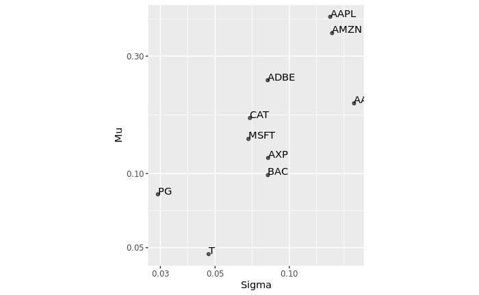

```r
ggplot(mult_sigma,aes(x=Sigma, y=Mu,label=Group.1)) + geom_point(alpha =0.6) + coord_fixed() + scale_x_log10() + scale_y_log10() + geom_text(aes(label=Group.1),hjust=0, vjust=0)
```

```r
ggplot(mult_musig,aes(x=Sigma, y=Mu),) + geom_point(alpha =0.6) + coord_fixed() + scale_x_log10() + scale_y_log10() + stat_smooth(method = "lm",col = "#C42126",se = FALSE, size=1)
```

[output not shown]

## Exercise 3: Rolling regressions

Perform static and rolling regressions of four of your assets (monthly data, yearly window) on the S&P500 as well as the three Fama-French Factors (Mkt.RF, SMB and HML). Visualize the changing alphas and betas over time. You can use [this example](https://www.business-science.io/code-tools/2017/04/04/tidyquant-0-5-0.html), but I would prefer a use of the `tsibble`-package.

```r
SP500_Stocks <- tq_index("S&P500")
```

```
Getting holdings for SP500
```

```r
SP500_2000 <- tq_get(SP500_Stocks,
                      get  = "stock.prices",
                      from = "2000-12-01",
                      to   = "2000-12-31", periode = "monthly")
```

[output not shown]

Then, we select our 4 stocks.

```r
SP500_2<-c("AMZN", "ADBE", "MSFT", "AAL") %>% tq_get(get  = "stock.prices",from = "2000-12-25", to   = "2018-12-31")

SP500_2000<-slice(SP500_2,1:10)
```

Next, we download fama-french.

```r
factors_data_address <- "http://mba.tuck.dartmouth.edu/pages/faculty/ken.french/ftp/Global_3_Factors_CSV.zip"
factors_csv_name <- "Global_3_Factors.csv"
temp <- tempfile()

download.file(
  # this is the location of the file to be downloaded
  factors_data_address,
  # here we want to store the file
  temp,
  quiet = TRUE)
#Now, we want to read the file and get the data from 2000-01-01 to 2018-12-31
factors <-
  read_csv(unz(temp, "Global_3_Factors.csv"),
           skip = 3) %>%
  dplyr::rename(date = X1) %>%
  dplyr::rename(mktrf = 'Mkt-RF') %>%
  dplyr::rename(rf = RF) %>%
  mutate_at(vars(-date), as.numeric) %>%
  mutate(date =
           rollback(ymd(parse_date_time(date, "%Y%m") + months(1))))%>%
  filter(date >=
   first('2000-01-01') & date <=
   '2018-12-31')
```

[output not shown]

```r
names(factors)[names(factors) == "date"] <- "X1" %>%
names(factors)[names(factors) == "mktrf"] <- "MktRF" %>%
names(factors)[names(factors) == "rf"] <- "RF" %>%
```

[output not shown]

Now, we want the monthly stock returns.

```r
pacman::p_load(tidyverse,tidyquant,timetk)
fama_french <- filter(factors, date >= as.Date("2000-01-01"), date <= as.Date("2019-08-31"))
fama_french <- fama_french %>%
select(date, mktrf, rf)
fama_french
```

| date | mktrf | rf |
| --- | --- | --- |
| 2000-01-31 | -5.37 | 0.41 |
| 2000-02-29 | 2.30 | 0.43 |
| 2000-03-31 | 4.66 | 0.47 |
| 2000-04-30 | -5.77 | 0.46 |
| 2000-05-31 | -3.29 | 0.50 |
| 2000-06-30 | 3.28 | 0.40 |
| 2000-07-31 | -3.39 | 0.48 |
| 2000-08-31 | 4.21 | 0.50 |
| 2000-09-30 | -5.24 | 0.51 |
| 2000-10-31 | -3.53 | 0.56 |

[output cut: 218 more lines]

```r
# Now, we create a function in order to deliver the monthly returns since 2000
get_monthly_returns <- function(symbol){
  return <- tq_transmute(tq_get(symbol,
                                get = "stock.prices",
                                from = "2000-01-01",
                                to = "2019-08-31"),
                         select = adjusted,
                         col_rename = "monthly_return",
                         mutate_fun = periodReturn,
                         period = "monthly") %>%
    mutate(monthly_return = monthly_return * 100)
}
#Now, we want the returns for our four stocks
amzn_return <- get_monthly_returns("AMZN")
```

[output not shown]

```r
adbe_return <- get_monthly_returns("ADBE")
msft_return <- get_monthly_returns("MSFT")
aal_return <- get_monthly_returns("AAL")
```

Next, we want to merge the two datasets - the stock returns and fama_french

```r
joined_data_amzn <- left_join(amzn_return, fama_french, by = NULL)
joined_data_amzn
```

| date | monthly_return | mktrf | rf |
| --- | --- | --- | --- |
| 2000-01-31 | -27.76223776 | -5.37 | 0.41 |
| 2000-02-29 | 6.67957406 | 2.30 | 0.43 |
| 2000-03-31 | -2.72232305 | 4.66 | 0.47 |
| 2000-04-28 | -17.63059701 | NA | NA |
| 2000-05-31 | -12.45753114 | -3.29 | 0.50 |
| 2000-06-30 | -24.83829237 | 3.28 | 0.40 |
| 2000-07-31 | -17.03958692 | -3.39 | 0.48 |
| 2000-08-31 | 37.75933610 | 4.21 | 0.50 |
| 2000-09-29 | -7.37951807 | NA | NA |
| 2000-10-31 | -4.71544715 | -3.53 | 0.56 |

[output cut: 226 more lines]

```r
joined_data_adbe <- left_join(adbe_return, fama_french, by = NULL)
joined_data_adbe
```

| date | monthly_return | mktrf | rf |
| --- | --- | --- | --- |
| 2000-01-31 | -16.0152649 | -5.37 | 0.41 |
| 2000-02-29 | 85.2440779 | 2.30 | 0.43 |
| 2000-03-31 | 9.1566271 | 4.66 | 0.47 |
| 2000-04-28 | 8.6468395 | NA | NA |
| 2000-05-31 | -6.9250724 | -3.29 | 0.50 |
| 2000-06-30 | 15.5146154 | 3.28 | 0.40 |
| 2000-07-31 | -11.9230661 | -3.39 | 0.48 |
| 2000-08-31 | 13.5371039 | 4.21 | 0.50 |
| 2000-09-29 | 19.4432520 | NA | NA |
| 2000-10-31 | -2.0129100 | -3.53 | 0.56 |

[output cut: 226 more lines]

```r
joined_data_msft <- left_join(msft_return, fama_french, by = NULL)
joined_data_msft
```

| date | monthly_return | mktrf | rf |
| --- | --- | --- | --- |
| 2000-01-31 | -16.0322148 | -5.37 | 0.41 |
| 2000-02-29 | -8.6845273 | 2.30 | 0.43 |
| 2000-03-31 | 18.8811759 | 4.66 | 0.47 |
| 2000-04-28 | -34.3529581 | NA | NA |
| 2000-05-31 | -10.3046650 | -3.29 | 0.50 |
| 2000-06-30 | 27.8720782 | 3.28 | 0.40 |
| 2000-07-31 | -12.7343329 | -3.39 | 0.48 |
| 2000-08-31 | 0.0000000 | 4.21 | 0.50 |
| 2000-09-29 | -13.6078896 | NA | NA |
| 2000-10-31 | 14.1968849 | -3.53 | 0.56 |

[output cut: 226 more lines]

```r
joined_data_aal <- left_join(aal_return, fama_french, by = NULL)
joined_data_aal
```

| date | monthly_return | mktrf | rf |
| --- | --- | --- | --- |
| 2005-09-30 | 8.86010978 | 2.08 | 0.29 |
| 2005-10-31 | 17.46786578 | -2.68 | 0.27 |
| 2005-11-30 | 36.10208838 | 2.90 | 0.31 |
| 2005-12-30 | 10.56864469 | NA | NA |
| 2006-01-31 | -21.00162738 | 4.52 | 0.35 |
| 2006-02-28 | 12.78119996 | -0.46 | 0.34 |
| 2006-03-31 | 20.88242991 | 2.43 | 0.37 |
| 2006-04-28 | 8.15002131 | NA | NA |
| 2006-05-31 | 7.95191604 | -4.12 | 0.43 |
| 2006-06-30 | 8.22269216 | -0.59 | 0.40 |

[output cut: 158 more lines]

In a next step, we calculate the reutrns minus the risk free rate. We combine monthly stock returns and risk factors.

```r
joined_data_amzn <- mutate(joined_data_amzn, monthly_ret_rf = monthly_return - rf)
joined_data_adbe <- mutate(joined_data_adbe, monthly_ret_rf = monthly_return - rf)
joined_data_msft <- mutate(joined_data_msft, monthly_ret_rf = monthly_return - rf)
joined_data_aal <- mutate(joined_data_aal, monthly_ret_rf = monthly_return - rf)
```

#rolling CAPM of our 4 stocks

In the next part, we want to create rolling CAPM of our4 stocks. We add the rolling CAPM to the Tibble ofr each Stock.

```r
require(zoo)

add_rolling_capm <- function(joined_data_symbol){
  regr_fun <- function(data_xts) {
    lm(monthly_ret_rf ~ mktrf, data = as_tibble(data_xts)) %>% coef()
  }

  return <- joined_data_symbol %>%
    tq_mutate(mutate_fun = rollapply,
              width = 60, # 60 data (tibble) rows // 60 rows / 12 months = 5 years
              FUN = regr_fun,
              by.column = FALSE,
              col_rename = c("alpha", "beta"))
}
joined_data_amzn <- add_rolling_capm(joined_data_amzn)
joined_data_adbe <- add_rolling_capm(joined_data_adbe)
joined_data_msft <- add_rolling_capm(joined_data_msft)
joined_data_aal <- add_rolling_capm(joined_data_aal)
```

#plotting ALPHA

In this part, we want to create plots for alpha.

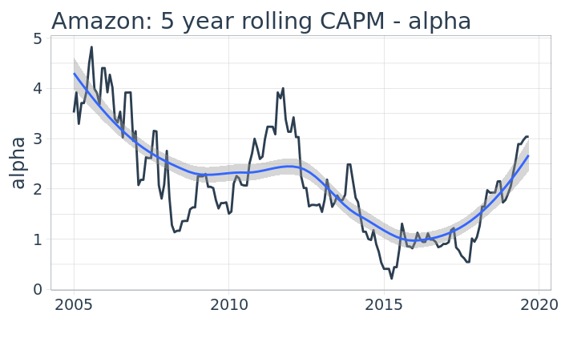

```r
create_alpha_plot <- function(joined_data_symbol, title) {
  filter(joined_data_symbol, !is.na(alpha)) %>%
    ggplot(aes(x = date, y = alpha)) +
        geom_line(size = 1, color = palette_light()[[1]]) +
        geom_smooth() +
        labs(title = title, x = "") +
        theme_tq(base_size = 18)
}
create_alpha_plot(joined_data_amzn, "Amazon: 5 year rolling CAPM - alpha")
```

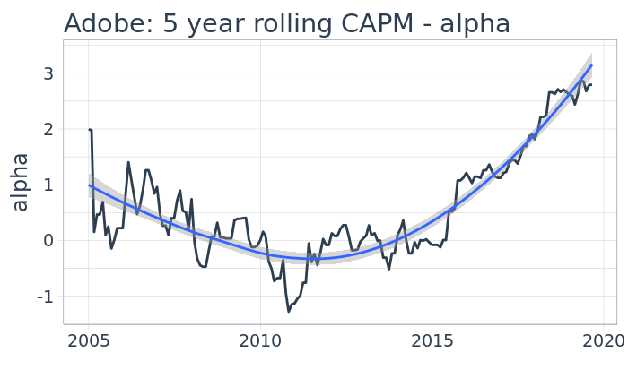

```r
create_alpha_plot(joined_data_adbe, "Adobe: 5 year rolling CAPM - alpha")
```

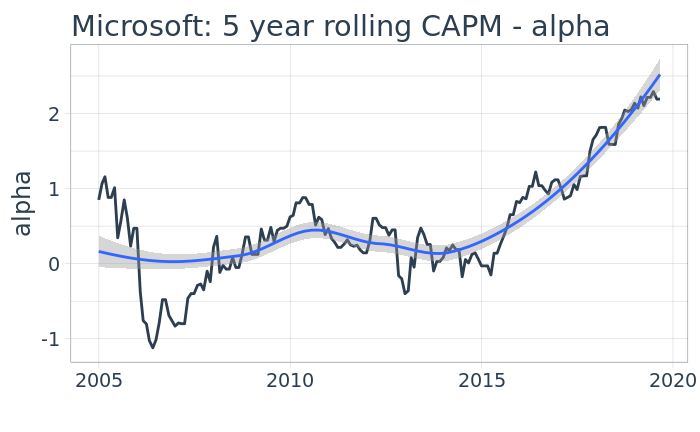

```r
create_alpha_plot(joined_data_msft, "Microsoft: 5 year rolling CAPM - alpha")
```

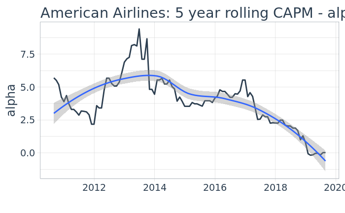

```r
create_alpha_plot(joined_data_aal, "American Airlines: 5 year rolling CAPM - alpha")
```

#plotting beta